# Análisis de diversidad metagenómica

Dulce I. Valdivia

Octubre 2022

En este manual se realizarán análisis básicos de diversidad y abundancia de muestras de metagenómica. Para poder llevar a acabo todos los pasos es necesario:

- **Datos**:
  - *Archivo de asignación taxonómica*. Archivo `.json` generado en el últmo paso del pipeline de metagenómica. Este archivo es un parseo del programa `kraken-biom` a la salida de asignación taxonómica generados por kraken (`.kraken.report`)
- **Paquetes de R**:
  - `phyloseq`: contiene las funciones necesarias para realizar los análisis correspondientes.
  - `tidyverse`: manipulación de datos.
  - `ggplot2` y `scico`: para hacer los gráficos de dichos análisis.

  A continuación se muestra cómo hacer la instalación de estos paquetes:

```r
  if (!require("BiocManager", quietly = TRUE))
    install.packages("BiocManager")
  BiocManager::install("phyloseq")
  install.packages("ggplot2")
  install.packages("scico")
  install.packages("tidyverse")
```

# 1 Carga de datos

Iniciamos carando los paquetes que necesitaremos:

```r
library(phyloseq)
library(ggplot2)
library(tidyverse)
library(scico)
```

Cargamos la asignación taxonómica generada:

```r
taxonomy <- import_biom("taxonomy_kraken.json")
```

# 2 Exploración inicial y limpieza de datos

Checamos el contenido del objeto taxonomy:

```r
# Información general:
  taxonomy
```

```
## phyloseq-class experiment-level object
## otu_table()   OTU Table:         [ 535 taxa and 3 samples ]
## tax_table()   Taxonomy Table:    [ 535 taxa by 7 taxonomic ranks ]
```

```r
# Conteo de taxa por muestra:
  taxonomy@otu_table %>% head()
```

```
## OTU Table:          [6 taxa and 3 samples]
##                      taxa are rows
##         SRR11131028.kraken SRR11131029.kraken SRR11131030.kraken
## 9604                649748             278860             182365
## 91347                11641                  1                757
## 1903409             204197                  0               1082
## 543                  15161               4761              10700
## 1903414               1405                  0               1094
## 1903411                885                182                597
```

```r
# Descripción de taxones:
  taxonomy@tax_table %>% head()
```

```
## Taxonomy Table:     [6 taxa by 7 taxonomic ranks]:
##         Rank1          Rank2               Rank3
## 9604    "k__Eukaryota" "p__Chordata"       "c__Mammalia"
## 91347   "k__Bacteria"  "p__Proteobacteria" "c__Gammaproteobacteria"
## 1903409 "k__Bacteria"  "p__Proteobacteria" "c__Gammaproteobacteria"
## 543     "k__Bacteria"  "p__Proteobacteria" "c__Gammaproteobacteria"
## 1903414 "k__Bacteria"  "p__Proteobacteria" "c__Gammaproteobacteria"
## 1903411 "k__Bacteria"  "p__Proteobacteria" "c__Gammaproteobacteria"
##         Rank4                 Rank5                   Rank6 Rank7
## 9604    "o__Primates"         "f__Hominidae"          "g__" "s__"
## 91347   "o__Enterobacterales" "f__"                   "g__" "s__"
## 1903409 "o__Enterobacterales" "f__Erwiniaceae"        "g__" "s__"
## 543     "o__Enterobacterales" "f__Enterobacteriaceae" "g__" "s__"
## 1903414 "o__Enterobacterales" "f__Morganellaceae"     "g__" "s__"
## 1903411 "o__Enterobacterales" "f__Yersiniaceae"       "g__" "s__"
```

```r
  # O bien:
  taxonomy@tax_table@.Data %>% head()
```

```
##         Rank1          Rank2               Rank3
## 9604    "k__Eukaryota" "p__Chordata"       "c__Mammalia"
## 91347   "k__Bacteria"  "p__Proteobacteria" "c__Gammaproteobacteria"
## 1903409 "k__Bacteria"  "p__Proteobacteria" "c__Gammaproteobacteria"
## 543     "k__Bacteria"  "p__Proteobacteria" "c__Gammaproteobacteria"
## 1903414 "k__Bacteria"  "p__Proteobacteria" "c__Gammaproteobacteria"
## 1903411 "k__Bacteria"  "p__Proteobacteria" "c__Gammaproteobacteria"
##         Rank4                 Rank5                   Rank6 Rank7
## 9604    "o__Primates"         "f__Hominidae"          "g__" "s__"
## 91347   "o__Enterobacterales" "f__"                   "g__" "s__"
## 1903409 "o__Enterobacterales" "f__Erwiniaceae"        "g__" "s__"
## 543     "o__Enterobacterales" "f__Enterobacteriaceae" "g__" "s__"
## 1903414 "o__Enterobacterales" "f__Morganellaceae"     "g__" "s__"
## 1903411 "o__Enterobacterales" "f__Yersiniaceae"       "g__" "s__"
```

```r
  # Limpiar etiquetas:
  taxonomy@tax_table@.Data <- substring(taxonomy@tax_table@.Data, 4)

  # Renombrar columnas:
  colnames(taxonomy@tax_table@.Data) <- c("Kingdom",
                                          "Phylum",
                                          "Class",
                                          "Order",
                                          "Family",
                                          "Genus",
                                          "Species")

  # Explorar resultado:
  taxonomy@tax_table@.Data %>% head()
```

```
##         Kingdom     Phylum           Class                 Order
## 9604    "Eukaryota" "Chordata"       "Mammalia"            "Primates"
## 91347   "Bacteria"  "Proteobacteria" "Gammaproteobacteria" "Enterobacterales"
## 1903409 "Bacteria"  "Proteobacteria" "Gammaproteobacteria" "Enterobacterales"
## 543     "Bacteria"  "Proteobacteria" "Gammaproteobacteria" "Enterobacterales"
## 1903414 "Bacteria"  "Proteobacteria" "Gammaproteobacteria" "Enterobacterales"
## 1903411 "Bacteria"  "Proteobacteria" "Gammaproteobacteria" "Enterobacterales"
##         Family               Genus Species
## 9604    "Hominidae"          ""    ""
## 91347   ""                   ""    ""
## 1903409 "Erwiniaceae"        ""    ""
## 543     "Enterobacteriaceae" ""    ""
## 1903414 "Morganellaceae"     ""    ""
## 1903411 "Yersiniaceae"       ""    ""
```

Con esta primer limpieza podemos explorar cuántos linajes distintos se asignaron a los distintos niveles taxonómicos. Checamos los tres más altos:

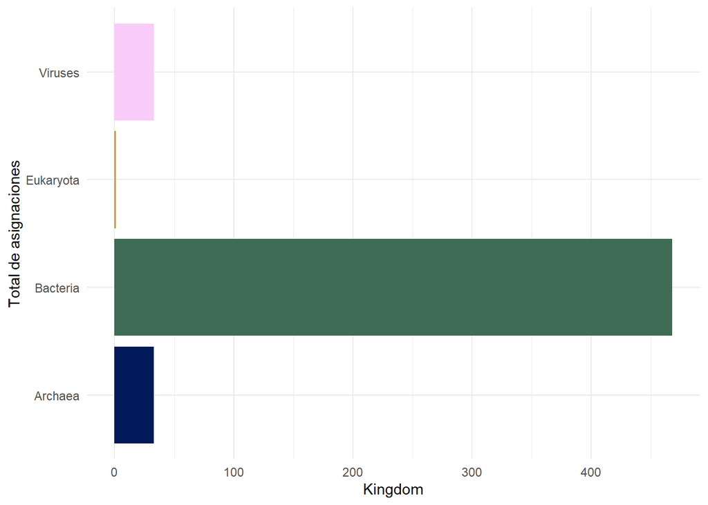

```r
taxonomy@tax_table@.Data %>%
  as_tibble() %>%
  group_by(Kingdom) %>%
  count() %>%
  ggplot(aes(x = Kingdom, y = n, fill = Kingdom)) +
      geom_bar(stat = "identity") +
      coord_flip() +
      scale_fill_scico_d(palette = "batlow") +
      labs(x = "Total de asignaciones",
           y = "Kingdom") +
      theme_minimal() +
      theme(legend.position = "none")
```

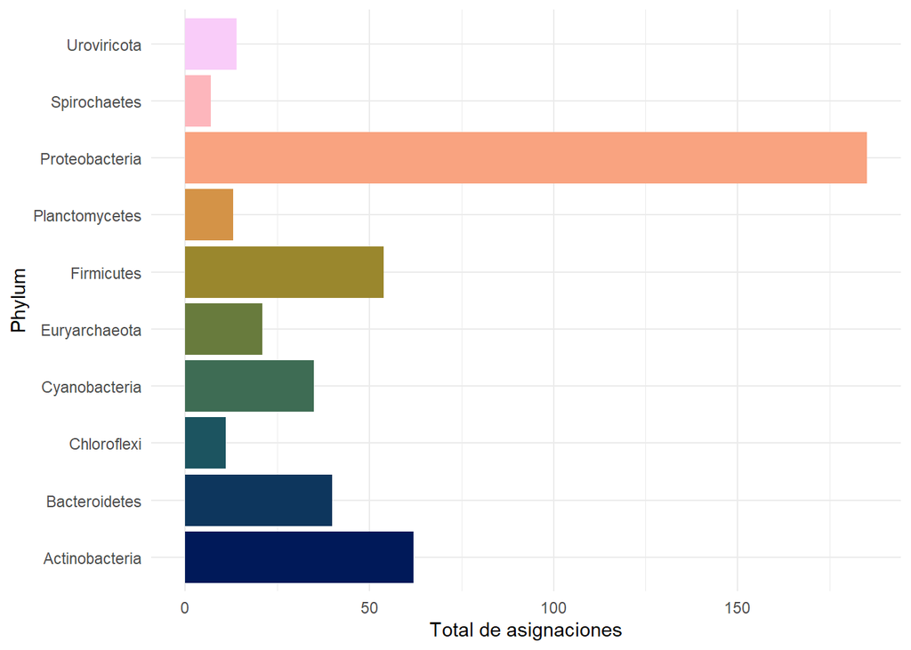

```r
taxonomy@tax_table@.Data %>%
  as_tibble() %>%
  group_by(Phylum) %>%
  count() %>%
  arrange(desc(n)) %>%
  head(10) %>%
  ggplot(aes(x = Phylum, y = n, fill = Phylum)) +
      geom_bar(stat = "identity") +
      scale_fill_scico_d(palette = "batlow") +
      labs(y = "Total de asignaciones",
           x = "Phylum") +
      theme_minimal() +
      coord_flip() +
      theme(legend.position = "none")
```

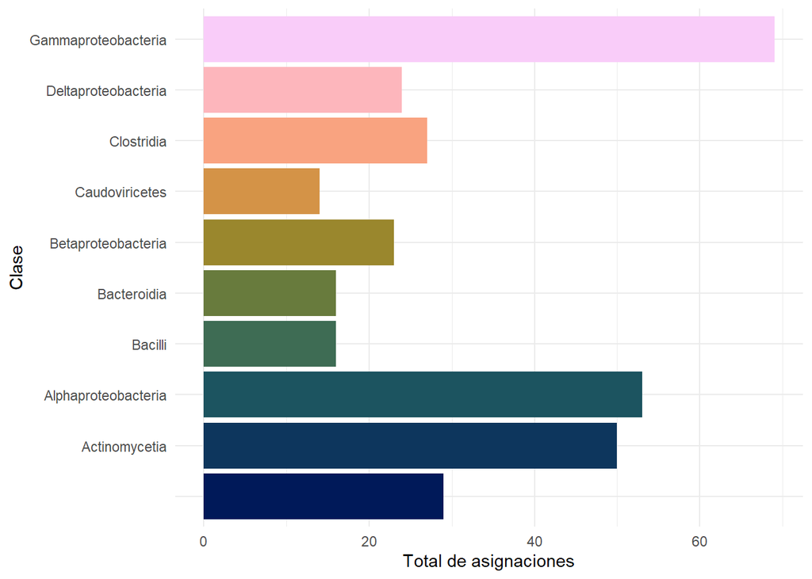

```r
taxonomy@tax_table@.Data %>%
  as_tibble() %>%
  group_by(Class) %>%
  count() %>%
  arrange(desc(n)) %>%
  head(10) %>%
  ggplot(aes(x = Class, y = n, fill = Class)) +
      geom_bar(stat = "identity") +
      scale_fill_scico_d(palette = "batlow") +
      labs(y = "Total de asignaciones",
           x = "Clase") +
      coord_flip() +
      theme_minimal() +
      theme(legend.position = "none")
```

Como vimos en la exploración por taxón, se encontraron algunos virus a nivel de reino. Ahora limpiaremos las asignaciones correspondientes a virus, mitocondrias o cloroplastos:

```r
taxonomy <- subset_taxa(taxonomy,Kingdom != "Viruses" &
                                Family != "mitochondria" &
                                Class != "Chloroplast")
```

Una vez limpios nuestros datos, podemos volver a hacer las gráficas anteriores para visualizar los totales limpios.

# 3 Abundancia taxonómica

En esta sección exploraremos la composición taxonómica y de abundancia en las tres muestras.

Primero generaremos el porcentaje de **abundancia** de cada taxa en cada muestra y limitaremos el estudio a nivel de **phylum**.

```r
  # Calculamos los porcentajes de abundancia por muestra
  percentages <- transform_sample_counts(taxonomy,
                                         function(x) x * 100 / sum(x))
  # Verificamos:
  percentages@otu_table@.Data %>% head
```

```
##         SRR11131028.kraken SRR11131029.kraken SRR11131030.kraken
## 9604           61.94483056       1.221219e+00        12.20927119
## 91347           1.10981453       4.379326e-06         0.05068088
## 1903409        19.46746826       0.000000e+00         0.07243951
## 543             1.44539972       2.084997e-02         0.71636115
## 1903414         0.13394806       0.000000e+00         0.07324291
## 1903411         0.08437298       7.970373e-04         0.03996894
```

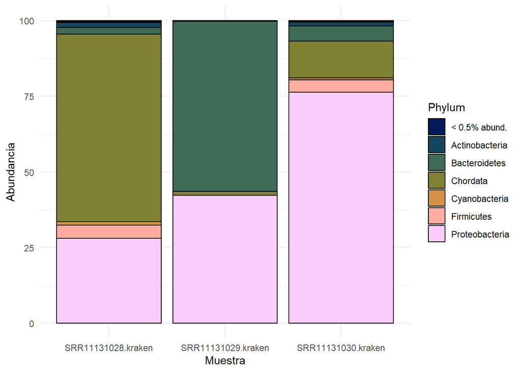

```r
  # Nos quedamos con los datos a nivel de Phylum y
  # aquellos phyla que tengan una abundancia menor
  # de <0.5 las colapsamos en una misma clase para la
  # visualización.
  phylaTax <- tax_glom(percentages, taxrank = "Phylum") %>%
                  psmelt() %>%
                  as_tibble() %>%
                  mutate(Label = ifelse(Abundance < 0.5,
                            "< 0.5% abund.",
                            Phylum))
  # Visualizamos:
  phylaTax %>%
        ggplot(aes(x = Sample, y = Abundance, fill = Label)) +
            geom_bar(stat = "identity",
                     position = "stack",
                     color = "black") +
            labs(x = "Muestra", y = "Abundancia", fill = "Phylum") +
            scale_fill_scico_d(palette = "batlow") +
            theme_minimal()
```

```r
  # Para ver aquellos phyla con poca abundancia (<0.5):
  phylaTax %>%
      filter(Label == "< 0.5% abund.") %>%
      dplyr::select(Phylum) %>%
      unique()
```

```
## # A tibble: 46 x 1
##    Phylum
##    <chr>
##  1 Spirochaetes
##  2 Firmicutes
##  3 Planctomycetes
##  4 Tenericutes
##  5 Chloroflexi
##  6 Euryarchaeota
##  7 Fusobacteria
##  8 Verrucomicrobia
##  9 Candidatus Saccharibacteria
## 10 Deinococcus-Thermus
## # ... with 36 more rows
```

# 4 Análisis de diversidad

Una vez que analizamos la composición y abundancia taxonómica de las muestras, vamos a analizar cómo es su diversidad. La diversidad alfa, explica la diversidad *dentro de cada muestra*, mientras que la diversidad beta analiza la diversidad *entre las distintas muestras*.

## 4.1 Diversidad alpha

La función ``plot_richness` calcula los distintos índices de diversidad al mismo tiempo y provee el gráfico base de estos valores.

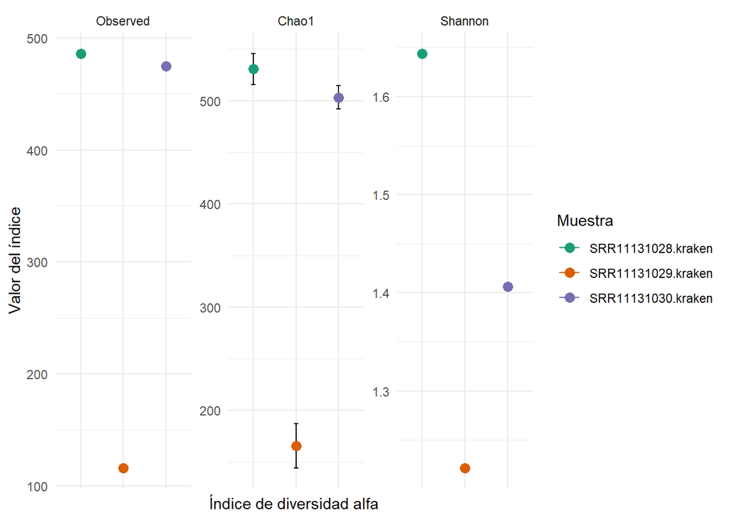

```r
  # Hacemos el grafico de los distintos indices de diversidad
  # y lo guardamos en una variable para poder acceder posteriormente
  # a los datos crudos.

  alfaDiv <- plot_richness(taxonomy,
                measures = c("Observed",
                             "Chao1",
                             "Shannon")) +
                geom_point(aes(color = samples), size = 3) +
                scale_color_brewer(palette = "Dark2") +
                labs(x = "Índice de diversidad alfa",
                     y = "Valor del índice",
                     color = "Muestra") +
                theme_minimal() +
                theme(axis.text.x = element_blank())

  # Visualizamos el grafico:
  alfaDiv
```

```r
  # Consultamos los datos crudos:
  alfaDiv$data
```

```
##              samples variable      value       se
## 1 SRR11131028.kraken Observed 486.000000       NA
## 2 SRR11131029.kraken Observed 116.000000       NA
## 3 SRR11131030.kraken Observed 475.000000       NA
## 4 SRR11131028.kraken    Chao1 530.634146 14.99520
## 5 SRR11131029.kraken    Chao1 165.400000 21.40188
## 6 SRR11131030.kraken    Chao1 503.218750 11.32118
## 7 SRR11131028.kraken  Shannon   1.643707       NA
## 8 SRR11131029.kraken  Shannon   1.221503       NA
## 9 SRR11131030.kraken  Shannon   1.406291       NA
```

## 4.2 Diversidad beta

Existen varias formas de calcular la diversidad beta. Aquí se muestra el método NMDS con distancia Bray-Curtis. El objetivo del método NMDS es hacer un análisis de reducción de dimensionalidad entre las muestras de manera que si fuesen similares generarían clusters en la representación 2D.

```r
# Calculamos con la funcion ordinate
  betaDiv <- ordinate(percentages,
                      method = "NMDS",
                      distance = "bray")
```

```
## Square root transformation
## Wisconsin double standardization
## *** No convergence -- monoMDS stopping criteria:
##     20: stress < smin
```

```r
# Hacemos el grafico inicial
  x <- plot_ordination(percentages,
                  ordination = betaDiv)
```

```
## No available covariate data to map on the points for this plot `type`
```

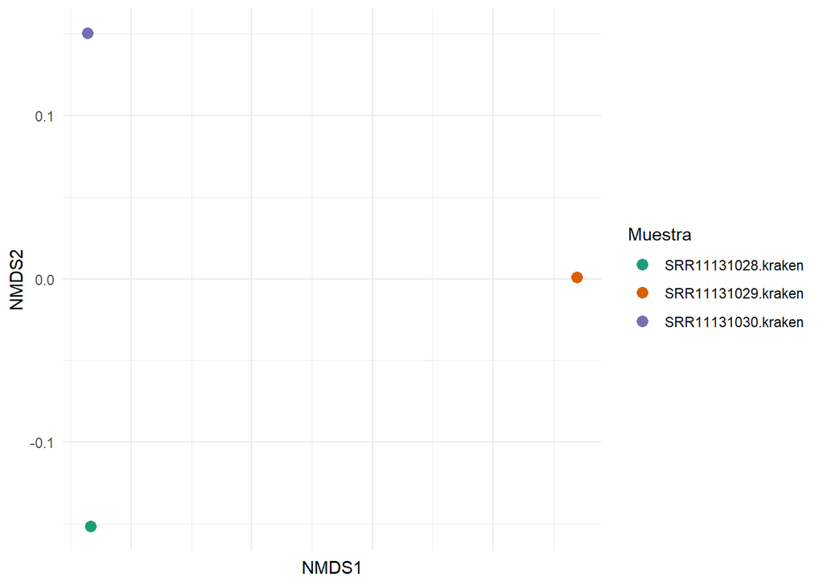

```r
# Agregamos la variable de la muestra para poder
# diferenciarlas en el grafico
  x$data <- x$data %>%
                mutate(muestra = rownames(x$data))

# Grafico final:
  x +
    geom_point(aes(color = muestra), size = 3) +
    scale_color_brewer(palette = "Dark2") +
    labs(color = "Muestra") +
    theme_minimal() +
    theme(axis.text.x = element_blank())
```

Observamos que nuestras muestras se encuentran muy separadas entre sí y, por lo tanto, son disímiles entre ellas. Para utilizar otros métodos y distancias puede consultarse la función `distanceMethodList`.